# Self-Driving Car Engineer Nanodegree

## Project: Build a Traffic Sign Recognition Classifier

In this notebook, a template is provided for you to implement your functionality in stages, which is required to successfully complete this project. If additional code is required that cannot be included in the notebook, be sure that the Python code is successfully imported and included in your submission if necessary.

In addition to implementing code, there is a writeup to complete. The writeup should be completed in a separate file, which can be either a markdown file or a pdf document. There is a [write up template](https://github.com/udacity/CarND-Traffic-Sign-Classifier-Project/blob/master/writeup_template.md) that can be used to guide the writing process. Completing the code template and writeup template will cover all of the [rubric points](https://review.udacity.com/#!/rubrics/481/view) for this project.

The [rubric](https://review.udacity.com/#!/rubrics/481/view) contains "Stand Out Suggestions" for enhancing the project beyond the minimum requirements. The stand out suggestions are optional. If you decide to pursue the "stand out suggestions", you can include the code in this Ipython notebook and also discuss the results in the writeup file.

> **Note:** Code and Markdown cells can be executed using the **Shift + Enter** keyboard shortcut. In addition, Markdown cells can be edited by typically double-clicking the cell to enter edit mode.

## Step 0: Load The Data

```python
# Load pickled data
import pickle

training_file = "./dataset/train.p"
validation_file= "./dataset/valid.p"
testing_file = "./dataset/test.p"

with open(training_file, mode='rb') as f:
    train = pickle.load(f)
with open(validation_file, mode='rb') as f:
    valid = pickle.load(f)
with open(testing_file, mode='rb') as f:
    test = pickle.load(f)

X_train, y_train = train['features'], train['labels']
X_valid, y_valid = valid['features'], valid['labels']
X_test, y_test = test['features'], test['labels']
```

## Step 1: Dataset Summary & Exploration

The pickled data is a dictionary with 4 key/value pairs:

- `'features'` is a 4D array containing raw pixel data of the traffic sign images, (num examples, width, height, channels).
- `'labels'` is a 1D array containing the label/class id of the traffic sign. The file `signnames.csv` contains id -> name mappings for each id.
- `'sizes'` is a list containing tuples, (width, height) representing the original width and height the image.
- `'coords'` is a list containing tuples, (x1, y1, x2, y2) representing coordinates of a bounding box around the sign in the image. **THESE COORDINATES ASSUME THE ORIGINAL IMAGE. THE PICKLED DATA CONTAINS RESIZED VERSIONS (32 by 32) OF THESE IMAGES**

Complete the basic data summary below. Use python, numpy and/or pandas methods to calculate the data summary rather than hard coding the results. For example, the [pandas shape method](http://pandas.pydata.org/pandas-docs/stable/generated/pandas.DataFrame.shape.html) might be useful for calculating some of the summary results.

### Provide a Basic Summary of the Data Set Using Python, Numpy and/or Pandas

```python
# numpy, pandas for data wrangling
import numpy as np
import pandas as pd

# To suppress incessant warning regarding future api change
import warnings
warnings.filterwarnings('ignore')

# Number of training examples
n_train = X_train.shape[0]

# Number of validation examples
n_validation = X_valid.shape[0]

# Number of testing examples.
n_test = X_test.shape[0]

# Number of examples in all dataset
total_n = n_train + n_validation + n_test

# Shape of an image
image_shape = X_train[0].shape

# The number of unique classes/labels in the dataset by using len, set and intersection
n_classes = len(set(y_train).intersection(y_valid).intersection(y_test))

print("Total number of examples =", total_n)
print("Number of training examples =", n_train, ", {}%".format(round(n_train/total_n*100)))
print("Number of validation examples =", n_validation, ", {}%".format(round(n_validation/total_n*100)))
print("Number of testing examples =", n_test, ", {}%".format(round(n_test/total_n*100)))
print("Image data shape =", image_shape)
print("Number of classes =", n_classes)
```

```
Total number of examples = 51839
Number of training examples = 34799 , 67%
Number of validation examples = 4410 , 9%
Number of testing examples = 12630 , 24%
Image data shape = (32, 32, 3)
Number of classes = 43
```

```python
# Create DataFrame - the number of instance per class in each train, validation and test set
df = pd.DataFrame()
for labelset, setname in zip([y_train, y_valid, y_test],["train","valid","test"]):
    lbl, counts = np.unique(labelset, return_counts=True)
    temp_df = pd.DataFrame(np.column_stack((lbl,counts)), columns=['label','count'])
    temp_df['set'] = setname
    df = df.append(temp_df).reset_index(drop=True)
```

```python
# a glimpse of the dataframe
df.head()
```

|  | label | count | set |
| --- | --- | --- | --- |
| 0 | 0 | 180 | train |
| 1 | 1 | 1980 | train |
| 2 | 2 | 2010 | train |
| 3 | 3 | 1260 | train |
| 4 | 4 | 1770 | train |

### Include an exploratory visualization of the dataset

Visualize the German Traffic Signs Dataset using the pickled file(s). This is open ended, suggestions include: plotting traffic sign images, plotting the count of each sign, etc.

The [Matplotlib](http://matplotlib.org/) [examples](http://matplotlib.org/examples/index.html) and [gallery](http://matplotlib.org/gallery.html) pages are a great resource for doing visualizations in Python.

**NOTE:** It's recommended you start with something simple first. If you wish to do more, come back to it after you've completed the rest of the sections. It can be interesting to look at the distribution of classes in the training, validation and test set. Is the distribution the same? Are there more examples of some classes than others?

```python
### Data exploration visualization code goes here.
### Feel free to use as many code cells as needed.
import matplotlib.pyplot as plt
# Visualizations will be shown in the notebook.
%matplotlib inline
```

```
<Container object of 43 artists>
```

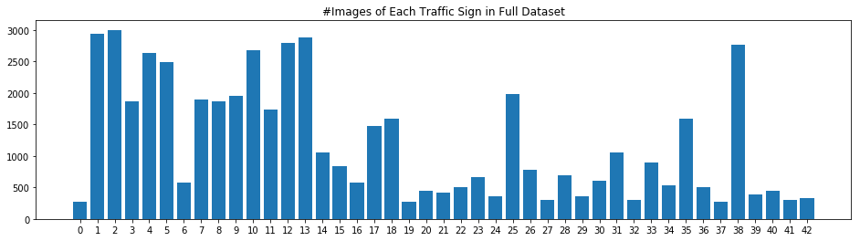

```python
# Number of Images of Each Traffic Sign in train + valid + test
lbl, counts = np.unique( np.concatenate([y_train, y_valid, y_test]), return_counts=True)
plt.figure(figsize=(16,4))
plt.xticks(range(43))
plt.title("#Images of Each Traffic Sign in Full Dataset")
plt.bar(lbl,counts)
```

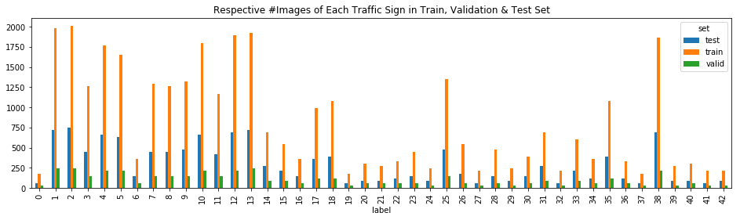

```python
# Number of Images of Each Traffic Sign in train + valid + test
df.pivot('label','set')['count'].plot(kind='bar', stacked=False, figsize=(16,4),
                                        title="Respective #Images of Each Traffic Sign in Train, Validation & Test Set")
```

```python
# Helper function to randomly pick and plot images from provided dataset
def rand_img_visualizer(image_dataset,image_labelset, rows=2, cols=10, cmap=None):
    # plotter object for all axes, assuming size 1.5 by 1.5 per images
    fig, ax = plt.subplots(rows, cols, figsize=(cols*1.5, rows*2))

    #random select rows*cols image index
    imgids = np.random.randint(0, len(image_dataset), rows*cols)

    for i, imgid in enumerate(imgids):
        r = int(i/cols)
        c = i%cols
        ax[r,c].imshow(image_dataset[imgid].squeeze(),cmap=cmap)
        ax[r,c].axis('off')
        ax[r,c].set_title("Id:" + str(imgid) + "\nClass: " + str(image_labelset[imgid]))
```

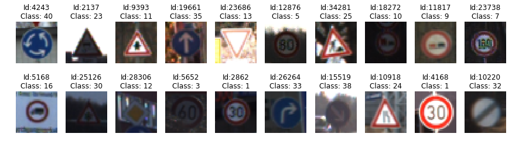

```python
# random visualization from train set
rand_img_visualizer(X_train,y_train)
```

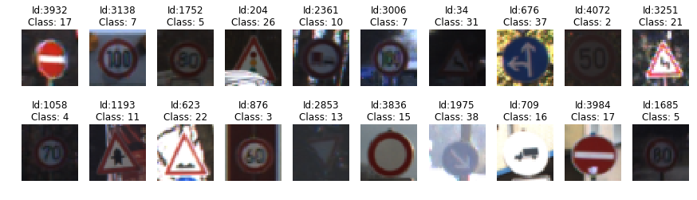

```python
# random visualization from validation set
rand_img_visualizer(X_valid,y_valid)
```

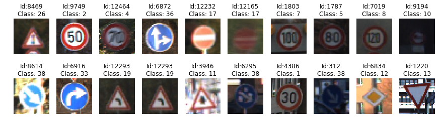

```python
# random visualization from test set
rand_img_visualizer(X_test,y_test)
```

## Step 2: Design and Test a Model Architecture

Design and implement a deep learning model that learns to recognize traffic signs. Train and test your model on the [German Traffic Sign Dataset](http://benchmark.ini.rub.de/?section=gtsrb&subsection=dataset).

The LeNet-5 implementation shown in the classroom at the end of the CNN lesson is a solid starting point. You'll have to change the number of classes and possibly the preprocessing, but aside from that it's plug and play!

With the LeNet-5 solution from the lecture, you should expect a validation set accuracy of about 0.89. To meet specifications, the validation set accuracy will need to be at least 0.93. It is possible to get an even higher accuracy, but 0.93 is the minimum for a successful project submission.

There are various aspects to consider when thinking about this problem:

- Neural network architecture (is the network over or underfitting?)
- Play around preprocessing techniques (normalization, rgb to grayscale, etc)
- Number of examples per label (some have more than others).
- Generate fake data.

Here is an example of a [published baseline model on this problem](http://yann.lecun.com/exdb/publis/pdf/sermanet-ijcnn-11.pdf). It's not required to be familiar with the approach used in the paper but, it's good practice to try to read papers like these.

### Pre-process the Data Set (normalization, grayscale, etc.)

Minimally, the image data should be normalized so that the data has mean zero and equal variance. For image data, `(pixel - 128)/ 128` is a quick way to approximately normalize the data and can be used in this project.

Other pre-processing steps are optional. You can try different techniques to see if it improves performance.

Use the code cell (or multiple code cells, if necessary) to implement the first step of your project.

###### Normalization Helper

```python
# Normalization helper
def normalize(dataset):
    #zero-center normalization
    dataset = (dataset.astype('float')-128)/128
    return dataset
```

###### Grayscaling Helper

```python
# Grayscaling helper
from skimage.color import rgb2gray

def grayscale(dataset):
    dataset = rgb2gray(dataset.astype('float'))

    # reshape to single channel from 3 channel
    return np.reshape(dataset, list(dataset.shape) + [1])
```

###### Pre-process: Grayscaling + Normalization

```python
# Preprocessing - grayscaling followed by normalization
X_train = normalize(grayscale(X_train))
X_valid = normalize(grayscale(X_valid))
X_test = normalize(grayscale(X_test))
```

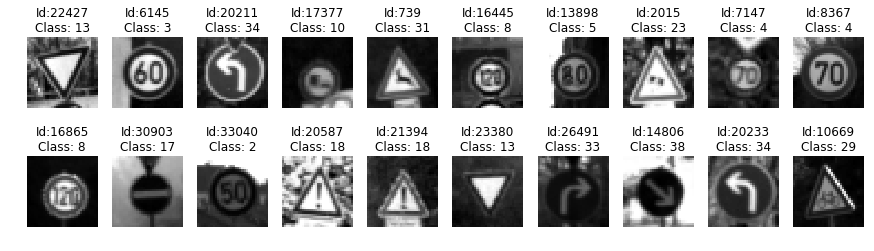

```python
# Visual inspection on train set if preprocessing performed as expected
rand_img_visualizer(X_train, y_train, cmap="gray")
```

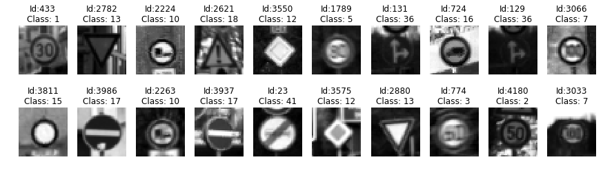

```python
# Visual inspection on validation set if preprocessing performed as expected
rand_img_visualizer(X_valid, y_valid, cmap="gray")
```

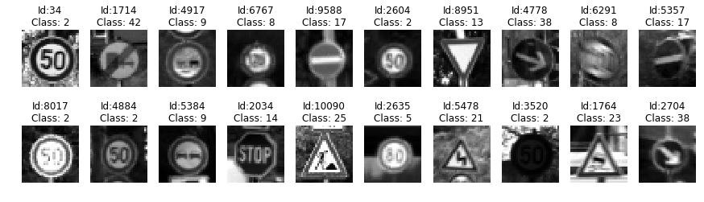

```python
# Visual inspection on test set if preprocessing performed as expected
rand_img_visualizer(X_test, y_test, cmap="gray")
```

### Data Augmentation

#### Rotation Set

```python
from skimage import transform #scikit-image for transformation API
from tqdm import tqdm # progress bar
```

```python
# Initialize rotation training set by copying from default training set
X_train_rot = np.copy(X_train)
y_train_rot = np.copy(y_train)
```

```python
# Rotation Transformation
# random sampling of angle to rotate between -15 to 15
angle = np.random.randint(-15,15, X_train_rot.shape[0])

for i in tqdm(range(X_train_rot.shape[0])):
    X_train_rot[i] = transform.rotate(image = X_train_rot[i].squeeze(),
                                      angle = angle[i],
                                      mode  = 'reflect').reshape(X_train_rot[i].shape)
```

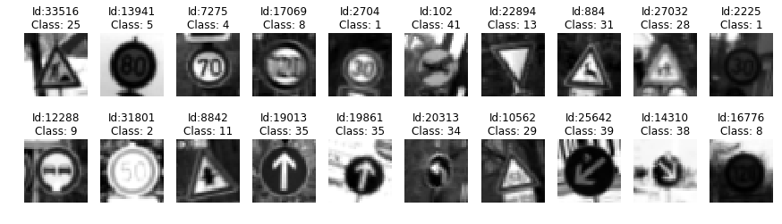

```python
# Randomly plot Rotated images
rand_img_visualizer(X_train_rot, y_train_rot, cmap="gray")
```

```python
# Visual inspection on rotation set
fig = plt.figure(figsize=(2.5,2.5))

b=fig.add_subplot(1,2,1)
b.set_title("Original")
b.axis('off')
plt.imshow(X_train[32874].squeeze(), cmap='gray')

a=fig.add_subplot(1,2,2)
a.set_title("Rotated")
a.axis('off')
plt.imshow(X_train_rot[32874].squeeze(), cmap='gray')
```

[output not shown]

#### Zoom Set

```python
# Zoom operation helper function
def zoom(img, scale=1.0):
    if scale == 1.0:
        return img

    elif scale < 1: # Zoom out
        new_w = int(img.shape[0] * scale)
        new_h = int(img.shape[1] * scale)
        pad_x = abs(img.shape[0] - new_w)
        pad_y = abs(img.shape[1] - new_h)
        pad_x1 = int(pad_x/2)
        pad_x2 = abs(pad_x - pad_x1)
        pad_y1 = int(pad_y/2)
        pad_y2 = abs(pad_y - pad_y1)
        return transform.resize(np.pad(img, ((pad_x1,pad_x2),(pad_y1,pad_y2),(0,0)),mode='reflect'), img.shape)

    elif scale > 1: # Zoom in
        new_w = int(img.shape[0] * scale)
        new_h = int(img.shape[1] * scale)
        offset_x = abs(new_w - img.shape[0])
        offset_y = abs(new_h - img.shape[1])
        x1 = int(offset_x/2)
        x2 = new_w - offset_x + x1
        y1 = int(offset_y/2)
        y2 = new_h - offset_y + y1
        return transform.resize(img, (new_w,new_h,img.shape[2]))[x1:x2,y1:y2,:]
```

```python
# Initialize zoom training set by copying from default training set
X_train_zoom = np.copy(X_train)
y_train_zoom = np.copy(y_train)
```

```python
# Zoom Transformation
# random sampling of scale to zoom between 0.9 to 1.1
scale = np.random.uniform(0.9, 1.0, X_train_zoom.shape[0])

for i in tqdm(range(X_train_zoom.shape[0])):
    X_train_zoom[i] = zoom(X_train_zoom[i], scale[i])
```

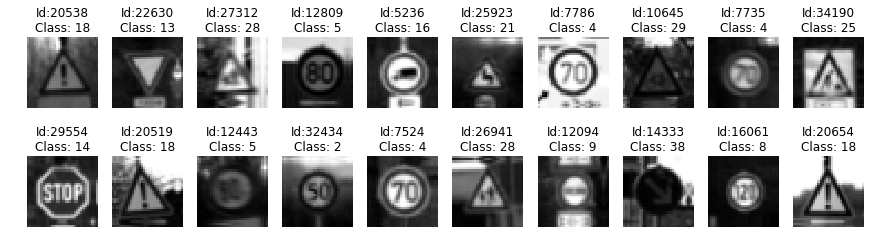

```python
# Randomly plot Zoomed images
rand_img_visualizer(X_train_zoom, y_train_zoom, cmap="gray")
```

```python
# Visual inspection on Zoom set
fig = plt.figure(figsize=(2.5,2.5))

b=fig.add_subplot(1,2,1)
b.set_title("Original")
b.axis('off')
plt.imshow(X_train[29330].squeeze(), cmap='gray')

a=fig.add_subplot(1,2,2)
a.set_title("Zoomed")
a.axis('off')
plt.imshow(X_train_zoom[29330].squeeze(), cmap='gray')
```

[output not shown]

#### Translation Set

```python
# Initialize translation training set by copying from default training set
X_train_translate = np.copy(X_train)
y_train_translate = np.copy(y_train)
```

```python
# random sampling of translation vector between -2 to 2 pixel
translation = list(zip(np.random.randint(-2,2, X_train_translate.shape[0]),
                       np.random.randint(-2,2,X_train_translate.shape[0])))

for i in tqdm(range(X_train_translate.shape[0])):
    X_train_translate[i] = transform.warp(X_train_translate[i], transform.AffineTransform(translation=translation[i]))
```

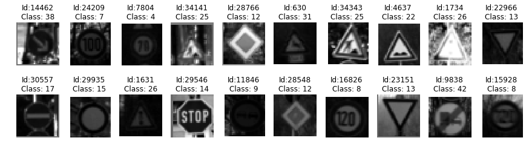

```python
# Randomly plot translated images
rand_img_visualizer(X_train_translate, y_train_translate, cmap="gray")
```

```python
# Visual inspection on Translation set
fig = plt.figure(figsize=(2.5,2.5))

b=fig.add_subplot(1,2,1)
b.set_title("Original")
b.axis('off')
plt.imshow(X_train[32673].squeeze(), cmap='gray')

a=fig.add_subplot(1,2,2)
a.set_title("Translated")
a.axis('off')
plt.imshow(X_train_translate[32673].squeeze(), cmap='gray')
```

[output not shown]

```python
# Check all augmented data in expected dimension
print(X_train.shape, X_train_rot.shape, X_train_zoom.shape, X_train_translate.shape)
```

```
(34799, 32, 32, 1) (34799, 32, 32, 1) (34799, 32, 32, 1) (34799, 32, 32, 1)
```

###### Augmented Dataset Consolidation

```python
# Consolidate all newly-created dataset
if 'data_augmentation_done' not in globals():
    X_train_Aug = np.concatenate([X_train,X_train_rot,X_train_translate,X_train_zoom])
    y_train_Aug = np.concatenate([y_train,y_train_rot,y_train_translate,y_train_zoom])

    # to avoid re-entering this loop to avoid multiple concatenation operation
    data_augmentation_done = True

print("Shape of train example set:", X_train_Aug.shape, "\nShape of train label set:", y_train_Aug.shape)
```

```
Shape of train example set: (139196, 32, 32, 1)
Shape of train label set: (139196,)
```

### Model Architecture

```python
### Define your architecture here.
### Feel free to use as many code cells as needed.
```

```python
# import tensorflow and relevant functions.
import tensorflow as tf
from tensorflow.contrib.layers import flatten
```

```python
gbl_seed = 9
tf.set_random_seed(gbl_seed)
```

```python
# set Epoch & Batch Size
EPOCHS = 10
BATCH_SIZE = 128
```

```python
# set grayscale as input
color_channel=1
```

```python
# features and labels
x = tf.placeholder(tf.float32, (None, 32, 32, color_channel))
y = tf.placeholder(tf.int32, (None))
one_hot_y = tf.one_hot(y, n_classes)
```

###### Model Architecture Helper Function

```python
# Configurable Model Architecture

def LeNet(x, color_channel=1, conv1_depth=6, conv2_depth=16, multiscale=False, dropout_keep_prob=None):
    # Arguments used for tf.truncated_normal, randomly defines variables for the weights for each layer
    mu = 0
    sigma = 0.1

    # ---------
    #Layer 1: Convolutional. Input = 32x32x1. Output = 28x28x conv1_depth.
    conv1_W = tf.Variable(tf.truncated_normal(shape=(5, 5, color_channel, conv1_depth), mean = mu, stddev = sigma, seed=gbl_seed))
    conv1_b = tf.Variable(tf.zeros(conv1_depth))
    conv1   = tf.nn.conv2d(x, conv1_W, strides=[1, 1, 1, 1], padding='VALID') + conv1_b

    # Layer 1: Activation.
    conv1_relu = tf.nn.relu(conv1)

    # Layer 1: Pooling. Input = 28x28x conv1_depth. Output = 14x14x conv1_depth.
    conv1_pool = tf.nn.max_pool(conv1_relu, ksize=[1, 2, 2, 1], strides=[1, 2, 2, 1], padding='VALID')

    # ---------
    # Layer 2: Convolutional. Input = 14x14x conv1_depth, Output = 10x10x conv2_depth.
    conv2_W = tf.Variable(tf.truncated_normal(shape=(5, 5, conv1_depth, conv2_depth), mean = mu, stddev = sigma, seed=gbl_seed))
    conv2_b = tf.Variable(tf.zeros(conv2_depth))
    conv2   = tf.nn.conv2d(conv1_pool, conv2_W, strides=[1, 1, 1, 1], padding='VALID') + conv2_b

    # Layer 2: Activation.
    conv2_relu = tf.nn.relu(conv2)

    # Layer 2: Pooling. Input = 10x10x conv2_depth. Output = 5x5x conv2_depth.
    conv2_pool = tf.nn.max_pool(conv2_relu, ksize=[1, 2, 2, 1], strides=[1, 2, 2, 1], padding='VALID')

    # ---------
    # Layer 3: Fully Connected.
    # Flattened input, if multiscaled enabled, input = 14*14* conv1_depth + 5*5* conv2_depth.
    # Else, input = 5*5* conv2_depth
    # Output = 120.
    pool1_shape = conv1_pool.get_shape().as_list()
    pool1_flatten = tf.reshape(conv1_pool,[-1, pool1_shape[1] * pool1_shape[2] * pool1_shape[3]])

    pool2_shape = conv2_pool.get_shape().as_list()
    pool2_flatten = tf.reshape(conv2_pool,[-1, pool2_shape[1] * pool2_shape[2] * pool2_shape[3]])

    if multiscale is True:
        fc_input = tf.concat(1, [pool1_flatten, pool2_flatten])
        fc_input_len = 14*14*conv1_depth + 5*5*conv2_depth
    else:
        fc_input = pool2_flatten
        fc_input_len = 5*5*conv2_depth

    # Dropout can be turned on in this layer
    if dropout_keep_prob is not None:
        if (dropout_keep_prob >= 0.0) & (dropout_keep_prob <= 1.0):
            fc_input = tf.nn.dropout(fc_input, keep_prob=dropout_keep_prob, seed=gbl_seed)

    # Layer 3: Fully Connected. Input = as explained above. Output = 120.
    fc1_W = tf.Variable(tf.truncated_normal(shape=(fc_input_len, 120), mean = mu, stddev = sigma, seed=gbl_seed))
    fc1_b = tf.Variable(tf.zeros(120))
    fc1   = tf.matmul(fc_input, fc1_W) + fc1_b

    # Layer 3: Activation.
    fc1_relu    = tf.nn.relu(fc1)

    # ---------
    # Layer 4: Fully Connected. Input = 120. Output = 84.
    fc2_W  = tf.Variable(tf.truncated_normal(shape=(120, 84), mean = mu, stddev = sigma, seed=gbl_seed))
    fc2_b  = tf.Variable(tf.zeros(84))
    fc2    = tf.matmul(fc1_relu, fc2_W) + fc2_b

    # Layer 4: Activation.
    fc2_relu    = tf.nn.relu(fc2)

    # ---------
    # Layer 5: Fully Connected. Input = 84. Output = n_classes.
    fc3_W  = tf.Variable(tf.truncated_normal(shape=(84, n_classes), mean = mu, stddev = sigma, seed=gbl_seed))
    fc3_b  = tf.Variable(tf.zeros(n_classes))
    logits = tf.matmul(fc2_relu, fc3_W) + fc3_b

    return logits, conv1, conv2
```

### Train, Validate and Test the Model

A validation set can be used to assess how well the model is performing. A low accuracy on the training and validation sets imply underfitting. A high accuracy on the training set but low accuracy on the validation set implies overfitting.

```python
### Train your model here.
### Calculate and report the accuracy on the training and validation set.
### Once a final model architecture is selected,
### the accuracy on the test set should be calculated and reported as well.
### Feel free to use as many code cells as needed.
```

```python
# Set Learning Rate
rate = 0.001

# Model Definition
logits, conv1, conv2 = LeNet(x)

# Cost Function
cross_entropy = tf.nn.softmax_cross_entropy_with_logits(labels=one_hot_y, logits=logits)
loss_operation = tf.reduce_mean(cross_entropy)

# Optimizer
optimizer = tf.train.AdamOptimizer(learning_rate = rate)

# Minimization/Training Operation
training_operation = optimizer.minimize(loss_operation)
```

```python
# Helper to evaluate accuracy on test set
prediction = tf.argmax(logits, 1)
y_hat = tf.nn.softmax(logits)
correct_prediction = tf.equal(tf.argmax(logits, 1), tf.argmax(one_hot_y, 1))
accuracy_operation = tf.reduce_mean(tf.cast(correct_prediction, tf.float32))
saver = tf.train.Saver()

def evaluate(X_data, y_data):
    num_examples = len(X_data)
    total_accuracy = 0
    sess = tf.get_default_session()
    for offset in range(0, num_examples, BATCH_SIZE):
        batch_x, batch_y = X_data[offset:offset+BATCH_SIZE], y_data[offset:offset+BATCH_SIZE]
        accuracy = sess.run(accuracy_operation, feed_dict={x: batch_x, y: batch_y})
        total_accuracy += (accuracy * len(batch_x))
    return total_accuracy / num_examples
```

```python
# Helper to launch training

from sklearn.utils import shuffle
import time

def launch_training(X_train=X_train,y_train=y_train, model_id=0):
    train_begin = time.perf_counter()

    with tf.Session() as sess:
        sess.run(tf.global_variables_initializer())
        num_examples = len(X_train)
        result = pd.DataFrame(columns=['Model_Id','Epoch',"Valid_Acc","Loss"])

        print("Training...")
        print()
        for i in range(EPOCHS):
            X_train, y_train = shuffle(X_train, y_train)
            for offset in range(0, num_examples, BATCH_SIZE):
                end = offset + BATCH_SIZE
                batch_x, batch_y = X_train[offset:end], y_train[offset:end]
                _, loss = sess.run([training_operation, loss_operation], feed_dict={x: batch_x, y: batch_y})

            validation_accuracy = evaluate(X_valid, y_valid)
            print("Model_id {}".format(model_id),", EPOCH {} ...".format(i+1),
                  ", Validation Accuracy = {:.3f}".format(validation_accuracy),
                  ", Loss = {:.5f}".format(loss))
            result.loc[i] = [model_id,i,validation_accuracy,loss]

        saver.save(sess, './lenet_model_' + str(model_id))
        result.to_csv('./lenet_model_' + str(model_id) + '_log.csv', index=False)
        print("Model and Log saved.")

    train_elapsed = time.perf_counter() - train_begin
    print('Elapsed %.3f seconds.' % train_elapsed)
```

```python
# Helper to launch test accuracy evaluation

def launch_testing(X_test=X_test,y_test=y_test, model_id=0):
    with tf.Session() as sess:
        saver.restore(sess, tf.train.latest_checkpoint('.'))

        test_accuracy = evaluate(X_test, y_test)
        print("Model_id {}".format(model_id),", Test Accuracy = {:.3f}".format(test_accuracy))
```

### Model 0: Default Lenet5

```python
EPOCHS = 50
ID = 0
logits, conv1, conv2 = LeNet(x)
launch_training(model_id=ID)
launch_testing(model_id=ID)
```

```
Training...

Model_id 0 , EPOCH 1 ... , Validation Accuracy = 0.753 , Loss = 0.61844
Model_id 0 , EPOCH 2 ... , Validation Accuracy = 0.812 , Loss = 0.27317
Model_id 0 , EPOCH 3 ... , Validation Accuracy = 0.875 , Loss = 0.34084
Model_id 0 , EPOCH 4 ... , Validation Accuracy = 0.866 , Loss = 0.14267
Model_id 0 , EPOCH 5 ... , Validation Accuracy = 0.878 , Loss = 0.20447
Model_id 0 , EPOCH 6 ... , Validation Accuracy = 0.888 , Loss = 0.04182
Model_id 0 , EPOCH 7 ... , Validation Accuracy = 0.883 , Loss = 0.17582
Model_id 0 , EPOCH 8 ... , Validation Accuracy = 0.883 , Loss = 0.05000
Model_id 0 , EPOCH 9 ... , Validation Accuracy = 0.898 , Loss = 0.11310
Model_id 0 , EPOCH 10 ... , Validation Accuracy = 0.900 , Loss = 0.02039
Model_id 0 , EPOCH 11 ... , Validation Accuracy = 0.899 , Loss = 0.01576
Model_id 0 , EPOCH 12 ... , Validation Accuracy = 0.891 , Loss = 0.08564
Model_id 0 , EPOCH 13 ... , Validation Accuracy = 0.904 , Loss = 0.03805
Model_id 0 , EPOCH 14 ... , Validation Accuracy = 0.891 , Loss = 0.06169
Model_id 0 , EPOCH 15 ... , Validation Accuracy = 0.889 , Loss = 0.07139
Model_id 0 , EPOCH 16 ... , Validation Accuracy = 0.905 , Loss = 0.00834
Model_id 0 , EPOCH 17 ... , Validation Accuracy = 0.889 , Loss = 0.02341
Model_id 0 , EPOCH 18 ... , Validation Accuracy = 0.907 , Loss = 0.01279
Model_id 0 , EPOCH 19 ... , Validation Accuracy = 0.907 , Loss = 0.00258
Model_id 0 , EPOCH 20 ... , Validation Accuracy = 0.910 , Loss = 0.02611
Model_id 0 , EPOCH 21 ... , Validation Accuracy = 0.907 , Loss = 0.00554
Model_id 0 , EPOCH 22 ... , Validation Accuracy = 0.912 , Loss = 0.01120
Model_id 0 , EPOCH 23 ... , Validation Accuracy = 0.912 , Loss = 0.01067
Model_id 0 , EPOCH 24 ... , Validation Accuracy = 0.902 , Loss = 0.00349
Model_id 0 , EPOCH 25 ... , Validation Accuracy = 0.911 , Loss = 0.00507
Model_id 0 , EPOCH 26 ... , Validation Accuracy = 0.910 , Loss = 0.00104
Model_id 0 , EPOCH 27 ... , Validation Accuracy = 0.914 , Loss = 0.02284
Model_id 0 , EPOCH 28 ... , Validation Accuracy = 0.920 , Loss = 0.00213
Model_id 0 , EPOCH 29 ... , Validation Accuracy = 0.908 , Loss = 0.05629
Model_id 0 , EPOCH 30 ... , Validation Accuracy = 0.921 , Loss = 0.02257
Model_id 0 , EPOCH 31 ... , Validation Accuracy = 0.920 , Loss = 0.00126
Model_id 0 , EPOCH 32 ... , Validation Accuracy = 0.919 , Loss = 0.00454
Model_id 0 , EPOCH 33 ... , Validation Accuracy = 0.919 , Loss = 0.00408
Model_id 0 , EPOCH 34 ... , Validation Accuracy = 0.931 , Loss = 0.01118
Model_id 0 , EPOCH 35 ... , Validation Accuracy = 0.928 , Loss = 0.00016
Model_id 0 , EPOCH 36 ... , Validation Accuracy = 0.897 , Loss = 0.09859
Model_id 0 , EPOCH 37 ... , Validation Accuracy = 0.931 , Loss = 0.04418
Model_id 0 , EPOCH 38 ... , Validation Accuracy = 0.916 , Loss = 0.00341
Model_id 0 , EPOCH 39 ... , Validation Accuracy = 0.926 , Loss = 0.00031
Model_id 0 , EPOCH 40 ... , Validation Accuracy = 0.931 , Loss = 0.00058
Model_id 0 , EPOCH 41 ... , Validation Accuracy = 0.935 , Loss = 0.00603
Model_id 0 , EPOCH 42 ... , Validation Accuracy = 0.932 , Loss = 0.00031
Model_id 0 , EPOCH 43 ... , Validation Accuracy = 0.929 , Loss = 0.00024
Model_id 0 , EPOCH 44 ... , Validation Accuracy = 0.930 , Loss = 0.00003
Model_id 0 , EPOCH 45 ... , Validation Accuracy = 0.931 , Loss = 0.00012
Model_id 0 , EPOCH 46 ... , Validation Accuracy = 0.930 , Loss = 0.00042
Model_id 0 , EPOCH 47 ... , Validation Accuracy = 0.919 , Loss = 0.00155
Model_id 0 , EPOCH 48 ... , Validation Accuracy = 0.922 , Loss = 0.02259
Model_id 0 , EPOCH 49 ... , Validation Accuracy = 0.924 , Loss = 0.00072
Model_id 0 , EPOCH 50 ... , Validation Accuracy = 0.924 , Loss = 0.00161
Model and Log saved.
Elapsed 106.164 seconds.
Model_id 0 , Test Accuracy = 0.914
```

### Model 1: Lenet5, Deeper Conv2d

```python
EPOCHS = 50
ID = 1
logits, conv1, conv2 = LeNet(x, conv1_depth=12, conv2_depth=32)
launch_training(model_id=ID)
launch_testing(model_id=ID)
```

```
Training...

Model_id 1 , EPOCH 1 ... , Validation Accuracy = 0.689 , Loss = 0.88766
Model_id 1 , EPOCH 2 ... , Validation Accuracy = 0.834 , Loss = 0.45180
Model_id 1 , EPOCH 3 ... , Validation Accuracy = 0.869 , Loss = 0.21281
Model_id 1 , EPOCH 4 ... , Validation Accuracy = 0.885 , Loss = 0.30415
Model_id 1 , EPOCH 5 ... , Validation Accuracy = 0.891 , Loss = 0.17382
Model_id 1 , EPOCH 6 ... , Validation Accuracy = 0.890 , Loss = 0.07483
Model_id 1 , EPOCH 7 ... , Validation Accuracy = 0.893 , Loss = 0.09562
Model_id 1 , EPOCH 8 ... , Validation Accuracy = 0.892 , Loss = 0.04406
Model_id 1 , EPOCH 9 ... , Validation Accuracy = 0.903 , Loss = 0.07572
Model_id 1 , EPOCH 10 ... , Validation Accuracy = 0.906 , Loss = 0.02530
Model_id 1 , EPOCH 11 ... , Validation Accuracy = 0.903 , Loss = 0.07434
Model_id 1 , EPOCH 12 ... , Validation Accuracy = 0.890 , Loss = 0.04792
Model_id 1 , EPOCH 13 ... , Validation Accuracy = 0.915 , Loss = 0.04940
Model_id 1 , EPOCH 14 ... , Validation Accuracy = 0.924 , Loss = 0.03903
Model_id 1 , EPOCH 15 ... , Validation Accuracy = 0.899 , Loss = 0.01073
Model_id 1 , EPOCH 16 ... , Validation Accuracy = 0.905 , Loss = 0.04581
Model_id 1 , EPOCH 17 ... , Validation Accuracy = 0.898 , Loss = 0.02271
Model_id 1 , EPOCH 18 ... , Validation Accuracy = 0.902 , Loss = 0.01546
Model_id 1 , EPOCH 19 ... , Validation Accuracy = 0.901 , Loss = 0.00120
Model_id 1 , EPOCH 20 ... , Validation Accuracy = 0.927 , Loss = 0.05968
Model_id 1 , EPOCH 21 ... , Validation Accuracy = 0.908 , Loss = 0.00288
Model_id 1 , EPOCH 22 ... , Validation Accuracy = 0.904 , Loss = 0.02035
Model_id 1 , EPOCH 23 ... , Validation Accuracy = 0.914 , Loss = 0.02878
Model_id 1 , EPOCH 24 ... , Validation Accuracy = 0.919 , Loss = 0.00237
Model_id 1 , EPOCH 25 ... , Validation Accuracy = 0.922 , Loss = 0.00047
Model_id 1 , EPOCH 26 ... , Validation Accuracy = 0.924 , Loss = 0.04846
Model_id 1 , EPOCH 27 ... , Validation Accuracy = 0.920 , Loss = 0.01037
Model_id 1 , EPOCH 28 ... , Validation Accuracy = 0.912 , Loss = 0.02618
Model_id 1 , EPOCH 29 ... , Validation Accuracy = 0.922 , Loss = 0.00470
Model_id 1 , EPOCH 30 ... , Validation Accuracy = 0.915 , Loss = 0.02176
Model_id 1 , EPOCH 31 ... , Validation Accuracy = 0.914 , Loss = 0.00252
Model_id 1 , EPOCH 32 ... , Validation Accuracy = 0.932 , Loss = 0.00232
Model_id 1 , EPOCH 33 ... , Validation Accuracy = 0.911 , Loss = 0.00179
Model_id 1 , EPOCH 34 ... , Validation Accuracy = 0.903 , Loss = 0.00350
Model_id 1 , EPOCH 35 ... , Validation Accuracy = 0.925 , Loss = 0.00461
Model_id 1 , EPOCH 36 ... , Validation Accuracy = 0.908 , Loss = 0.00726
Model_id 1 , EPOCH 37 ... , Validation Accuracy = 0.918 , Loss = 0.02272
Model_id 1 , EPOCH 38 ... , Validation Accuracy = 0.927 , Loss = 0.00051
Model_id 1 , EPOCH 39 ... , Validation Accuracy = 0.904 , Loss = 0.00793
Model_id 1 , EPOCH 40 ... , Validation Accuracy = 0.919 , Loss = 0.00061
Model_id 1 , EPOCH 41 ... , Validation Accuracy = 0.927 , Loss = 0.00389
Model_id 1 , EPOCH 42 ... , Validation Accuracy = 0.915 , Loss = 0.13376
Model_id 1 , EPOCH 43 ... , Validation Accuracy = 0.921 , Loss = 0.00094
Model_id 1 , EPOCH 44 ... , Validation Accuracy = 0.932 , Loss = 0.00008
Model_id 1 , EPOCH 45 ... , Validation Accuracy = 0.933 , Loss = 0.00026
Model_id 1 , EPOCH 46 ... , Validation Accuracy = 0.933 , Loss = 0.00000
Model_id 1 , EPOCH 47 ... , Validation Accuracy = 0.934 , Loss = 0.00012
Model_id 1 , EPOCH 48 ... , Validation Accuracy = 0.934 , Loss = 0.00005
Model_id 1 , EPOCH 49 ... , Validation Accuracy = 0.935 , Loss = 0.00002
Model_id 1 , EPOCH 50 ... , Validation Accuracy = 0.934 , Loss = 0.00003
Model and Log saved.
Elapsed 106.649 seconds.
Model_id 1 , Test Accuracy = 0.917
```

### Model 2: Lenet5, Deeper Conv2d with Augmented Data

```python
EPOCHS = 50
ID = 2
logits, conv1, conv2 = LeNet(x, conv1_depth=12, conv2_depth=32)
launch_training(X_train=X_train_Aug,y_train=y_train_Aug, model_id=ID)
launch_testing(model_id=ID)
```

```
Training...

Model_id 2 , EPOCH 1 ... , Validation Accuracy = 0.862 , Loss = 0.29236
Model_id 2 , EPOCH 2 ... , Validation Accuracy = 0.890 , Loss = 0.14843
Model_id 2 , EPOCH 3 ... , Validation Accuracy = 0.897 , Loss = 0.16064
Model_id 2 , EPOCH 4 ... , Validation Accuracy = 0.915 , Loss = 0.04792
Model_id 2 , EPOCH 5 ... , Validation Accuracy = 0.914 , Loss = 0.02705
Model_id 2 , EPOCH 6 ... , Validation Accuracy = 0.920 , Loss = 0.04257
Model_id 2 , EPOCH 7 ... , Validation Accuracy = 0.913 , Loss = 0.00685
Model_id 2 , EPOCH 8 ... , Validation Accuracy = 0.926 , Loss = 0.06888
Model_id 2 , EPOCH 9 ... , Validation Accuracy = 0.936 , Loss = 0.00862
Model_id 2 , EPOCH 10 ... , Validation Accuracy = 0.933 , Loss = 0.00351
Model_id 2 , EPOCH 11 ... , Validation Accuracy = 0.922 , Loss = 0.01374
Model_id 2 , EPOCH 12 ... , Validation Accuracy = 0.922 , Loss = 0.01680
Model_id 2 , EPOCH 13 ... , Validation Accuracy = 0.918 , Loss = 0.00817
Model_id 2 , EPOCH 14 ... , Validation Accuracy = 0.943 , Loss = 0.00256
Model_id 2 , EPOCH 15 ... , Validation Accuracy = 0.933 , Loss = 0.01284
Model_id 2 , EPOCH 16 ... , Validation Accuracy = 0.921 , Loss = 0.03776
Model_id 2 , EPOCH 17 ... , Validation Accuracy = 0.935 , Loss = 0.00708
Model_id 2 , EPOCH 18 ... , Validation Accuracy = 0.944 , Loss = 0.00297
Model_id 2 , EPOCH 19 ... , Validation Accuracy = 0.924 , Loss = 0.00143
Model_id 2 , EPOCH 20 ... , Validation Accuracy = 0.933 , Loss = 0.00361
Model_id 2 , EPOCH 21 ... , Validation Accuracy = 0.937 , Loss = 0.00441
Model_id 2 , EPOCH 22 ... , Validation Accuracy = 0.940 , Loss = 0.00005
Model_id 2 , EPOCH 23 ... , Validation Accuracy = 0.938 , Loss = 0.02029
Model_id 2 , EPOCH 24 ... , Validation Accuracy = 0.943 , Loss = 0.00155
Model_id 2 , EPOCH 25 ... , Validation Accuracy = 0.930 , Loss = 0.00014
Model_id 2 , EPOCH 26 ... , Validation Accuracy = 0.946 , Loss = 0.00052
Model_id 2 , EPOCH 27 ... , Validation Accuracy = 0.940 , Loss = 0.00010
Model_id 2 , EPOCH 28 ... , Validation Accuracy = 0.941 , Loss = 0.00005
Model_id 2 , EPOCH 29 ... , Validation Accuracy = 0.931 , Loss = 0.03190
Model_id 2 , EPOCH 30 ... , Validation Accuracy = 0.953 , Loss = 0.05512
Model_id 2 , EPOCH 31 ... , Validation Accuracy = 0.947 , Loss = 0.00000
Model_id 2 , EPOCH 32 ... , Validation Accuracy = 0.953 , Loss = 0.00364
Model_id 2 , EPOCH 33 ... , Validation Accuracy = 0.948 , Loss = 0.02062
Model_id 2 , EPOCH 34 ... , Validation Accuracy = 0.937 , Loss = 0.00466
Model_id 2 , EPOCH 35 ... , Validation Accuracy = 0.937 , Loss = 0.00028
Model_id 2 , EPOCH 36 ... , Validation Accuracy = 0.940 , Loss = 0.01946
Model_id 2 , EPOCH 37 ... , Validation Accuracy = 0.941 , Loss = 0.00180
Model_id 2 , EPOCH 38 ... , Validation Accuracy = 0.946 , Loss = 0.00008
Model_id 2 , EPOCH 39 ... , Validation Accuracy = 0.944 , Loss = 0.00160
Model_id 2 , EPOCH 40 ... , Validation Accuracy = 0.941 , Loss = 0.00001
Model_id 2 , EPOCH 41 ... , Validation Accuracy = 0.939 , Loss = 0.00644
Model_id 2 , EPOCH 42 ... , Validation Accuracy = 0.941 , Loss = 0.00003
Model_id 2 , EPOCH 43 ... , Validation Accuracy = 0.941 , Loss = 0.00022
Model_id 2 , EPOCH 44 ... , Validation Accuracy = 0.936 , Loss = 0.00020
Model_id 2 , EPOCH 45 ... , Validation Accuracy = 0.941 , Loss = 0.00101
Model_id 2 , EPOCH 46 ... , Validation Accuracy = 0.935 , Loss = 0.00003
Model_id 2 , EPOCH 47 ... , Validation Accuracy = 0.927 , Loss = 0.00000
Model_id 2 , EPOCH 48 ... , Validation Accuracy = 0.948 , Loss = 0.00002
Model_id 2 , EPOCH 49 ... , Validation Accuracy = 0.952 , Loss = 0.28825
Model_id 2 , EPOCH 50 ... , Validation Accuracy = 0.931 , Loss = 0.00001
Model and Log saved.
Elapsed 411.201 seconds.
Model_id 2 , Test Accuracy = 0.932
```

### Model 3: Multi-scale Lenet5, with Augmented Data

```python
EPOCHS = 50
ID = 3
logits, conv1, conv2 = LeNet(x, conv1_depth=12, conv2_depth=32, multiscale=True)
launch_training(X_train=X_train_Aug,y_train=y_train_Aug, model_id=ID)
launch_testing(model_id=ID)
```

```
Training...

Model_id 3 , EPOCH 1 ... , Validation Accuracy = 0.863 , Loss = 0.32701
Model_id 3 , EPOCH 2 ... , Validation Accuracy = 0.905 , Loss = 0.18818
Model_id 3 , EPOCH 3 ... , Validation Accuracy = 0.905 , Loss = 0.25074
Model_id 3 , EPOCH 4 ... , Validation Accuracy = 0.912 , Loss = 0.06259
Model_id 3 , EPOCH 5 ... , Validation Accuracy = 0.927 , Loss = 0.05229
Model_id 3 , EPOCH 6 ... , Validation Accuracy = 0.928 , Loss = 0.02404
Model_id 3 , EPOCH 7 ... , Validation Accuracy = 0.938 , Loss = 0.01106
Model_id 3 , EPOCH 8 ... , Validation Accuracy = 0.931 , Loss = 0.01334
Model_id 3 , EPOCH 9 ... , Validation Accuracy = 0.927 , Loss = 0.01184
Model_id 3 , EPOCH 10 ... , Validation Accuracy = 0.920 , Loss = 0.05318
Model_id 3 , EPOCH 11 ... , Validation Accuracy = 0.936 , Loss = 0.00360
Model_id 3 , EPOCH 12 ... , Validation Accuracy = 0.942 , Loss = 0.00025
Model_id 3 , EPOCH 13 ... , Validation Accuracy = 0.930 , Loss = 0.02546
Model_id 3 , EPOCH 14 ... , Validation Accuracy = 0.927 , Loss = 0.07803
Model_id 3 , EPOCH 15 ... , Validation Accuracy = 0.948 , Loss = 0.04292
Model_id 3 , EPOCH 16 ... , Validation Accuracy = 0.939 , Loss = 0.00397
Model_id 3 , EPOCH 17 ... , Validation Accuracy = 0.947 , Loss = 0.00208
Model_id 3 , EPOCH 18 ... , Validation Accuracy = 0.953 , Loss = 0.04605
Model_id 3 , EPOCH 19 ... , Validation Accuracy = 0.947 , Loss = 0.00009
Model_id 3 , EPOCH 20 ... , Validation Accuracy = 0.933 , Loss = 0.00268
Model_id 3 , EPOCH 21 ... , Validation Accuracy = 0.945 , Loss = 0.00798
Model_id 3 , EPOCH 22 ... , Validation Accuracy = 0.937 , Loss = 0.00487
Model_id 3 , EPOCH 23 ... , Validation Accuracy = 0.950 , Loss = 0.00037
Model_id 3 , EPOCH 24 ... , Validation Accuracy = 0.954 , Loss = 0.00038
Model_id 3 , EPOCH 25 ... , Validation Accuracy = 0.934 , Loss = 0.00616
Model_id 3 , EPOCH 26 ... , Validation Accuracy = 0.942 , Loss = 0.00047
Model_id 3 , EPOCH 27 ... , Validation Accuracy = 0.951 , Loss = 0.03424
Model_id 3 , EPOCH 28 ... , Validation Accuracy = 0.950 , Loss = 0.01411
Model_id 3 , EPOCH 29 ... , Validation Accuracy = 0.946 , Loss = 0.00724
Model_id 3 , EPOCH 30 ... , Validation Accuracy = 0.949 , Loss = 0.00055
Model_id 3 , EPOCH 31 ... , Validation Accuracy = 0.948 , Loss = 0.00099
Model_id 3 , EPOCH 32 ... , Validation Accuracy = 0.949 , Loss = 0.00059
Model_id 3 , EPOCH 33 ... , Validation Accuracy = 0.953 , Loss = 0.00016
Model_id 3 , EPOCH 34 ... , Validation Accuracy = 0.946 , Loss = 0.00002
Model_id 3 , EPOCH 35 ... , Validation Accuracy = 0.952 , Loss = 0.08144
Model_id 3 , EPOCH 36 ... , Validation Accuracy = 0.944 , Loss = 0.00040
Model_id 3 , EPOCH 37 ... , Validation Accuracy = 0.931 , Loss = 0.01354
Model_id 3 , EPOCH 38 ... , Validation Accuracy = 0.947 , Loss = 0.00009
Model_id 3 , EPOCH 39 ... , Validation Accuracy = 0.948 , Loss = 0.01505
Model_id 3 , EPOCH 40 ... , Validation Accuracy = 0.953 , Loss = 0.00010
Model_id 3 , EPOCH 41 ... , Validation Accuracy = 0.949 , Loss = 0.00010
Model_id 3 , EPOCH 42 ... , Validation Accuracy = 0.937 , Loss = 0.00187
Model_id 3 , EPOCH 43 ... , Validation Accuracy = 0.947 , Loss = 0.00036
Model_id 3 , EPOCH 44 ... , Validation Accuracy = 0.941 , Loss = 0.00098
Model_id 3 , EPOCH 45 ... , Validation Accuracy = 0.949 , Loss = 0.02441
Model_id 3 , EPOCH 46 ... , Validation Accuracy = 0.945 , Loss = 0.07523
Model_id 3 , EPOCH 47 ... , Validation Accuracy = 0.949 , Loss = 0.00019
Model_id 3 , EPOCH 48 ... , Validation Accuracy = 0.932 , Loss = 0.00684
Model_id 3 , EPOCH 49 ... , Validation Accuracy = 0.954 , Loss = 0.00005
Model_id 3 , EPOCH 50 ... , Validation Accuracy = 0.948 , Loss = 0.00008
Model and Log saved.
Elapsed 409.314 seconds.
Model_id 3 , Test Accuracy = 0.941
```

### Model 4: Multi-scale Lenet5, with Augmented Data, Dropout Enabled

```python
EPOCHS = 50
ID = 4
logits, conv1, conv2 = LeNet(x, conv1_depth=12, conv2_depth=32, multiscale=True, dropout_keep_prob=0.90)
launch_training(X_train=X_train_Aug,y_train=y_train_Aug, model_id=ID)
launch_testing(model_id=ID)
```

```
Training...

Model_id 4 , EPOCH 1 ... , Validation Accuracy = 0.863 , Loss = 0.35045
Model_id 4 , EPOCH 2 ... , Validation Accuracy = 0.912 , Loss = 0.14335
Model_id 4 , EPOCH 3 ... , Validation Accuracy = 0.928 , Loss = 0.15177
Model_id 4 , EPOCH 4 ... , Validation Accuracy = 0.939 , Loss = 0.08662
Model_id 4 , EPOCH 5 ... , Validation Accuracy = 0.945 , Loss = 0.14258
Model_id 4 , EPOCH 6 ... , Validation Accuracy = 0.923 , Loss = 0.19708
Model_id 4 , EPOCH 7 ... , Validation Accuracy = 0.937 , Loss = 0.01904
Model_id 4 , EPOCH 8 ... , Validation Accuracy = 0.919 , Loss = 0.04015
Model_id 4 , EPOCH 9 ... , Validation Accuracy = 0.935 , Loss = 0.00808
Model_id 4 , EPOCH 10 ... , Validation Accuracy = 0.927 , Loss = 0.07270
Model_id 4 , EPOCH 11 ... , Validation Accuracy = 0.939 , Loss = 0.00594
Model_id 4 , EPOCH 12 ... , Validation Accuracy = 0.933 , Loss = 0.00354
Model_id 4 , EPOCH 13 ... , Validation Accuracy = 0.935 , Loss = 0.02598
Model_id 4 , EPOCH 14 ... , Validation Accuracy = 0.949 , Loss = 0.00169
Model_id 4 , EPOCH 15 ... , Validation Accuracy = 0.934 , Loss = 0.03508
Model_id 4 , EPOCH 16 ... , Validation Accuracy = 0.936 , Loss = 0.00119
Model_id 4 , EPOCH 17 ... , Validation Accuracy = 0.941 , Loss = 0.00113
Model_id 4 , EPOCH 18 ... , Validation Accuracy = 0.935 , Loss = 0.00231
Model_id 4 , EPOCH 19 ... , Validation Accuracy = 0.945 , Loss = 0.00034
Model_id 4 , EPOCH 20 ... , Validation Accuracy = 0.930 , Loss = 0.03012
Model_id 4 , EPOCH 21 ... , Validation Accuracy = 0.940 , Loss = 0.00067
Model_id 4 , EPOCH 22 ... , Validation Accuracy = 0.953 , Loss = 0.00102
Model_id 4 , EPOCH 23 ... , Validation Accuracy = 0.934 , Loss = 0.01129
Model_id 4 , EPOCH 24 ... , Validation Accuracy = 0.937 , Loss = 0.00161
Model_id 4 , EPOCH 25 ... , Validation Accuracy = 0.934 , Loss = 0.00026
Model_id 4 , EPOCH 26 ... , Validation Accuracy = 0.951 , Loss = 0.01292
Model_id 4 , EPOCH 27 ... , Validation Accuracy = 0.949 , Loss = 0.00020
Model_id 4 , EPOCH 28 ... , Validation Accuracy = 0.943 , Loss = 0.10168
Model_id 4 , EPOCH 29 ... , Validation Accuracy = 0.946 , Loss = 0.00010
Model_id 4 , EPOCH 30 ... , Validation Accuracy = 0.941 , Loss = 0.00127
Model_id 4 , EPOCH 31 ... , Validation Accuracy = 0.944 , Loss = 0.00224
Model_id 4 , EPOCH 32 ... , Validation Accuracy = 0.946 , Loss = 0.05739
Model_id 4 , EPOCH 33 ... , Validation Accuracy = 0.941 , Loss = 0.00000
Model_id 4 , EPOCH 34 ... , Validation Accuracy = 0.940 , Loss = 0.00066
Model_id 4 , EPOCH 35 ... , Validation Accuracy = 0.943 , Loss = 0.00005
Model_id 4 , EPOCH 36 ... , Validation Accuracy = 0.934 , Loss = 0.00022
Model_id 4 , EPOCH 37 ... , Validation Accuracy = 0.951 , Loss = 0.00029
Model_id 4 , EPOCH 38 ... , Validation Accuracy = 0.952 , Loss = 0.00002
Model_id 4 , EPOCH 39 ... , Validation Accuracy = 0.955 , Loss = 0.00006
Model_id 4 , EPOCH 40 ... , Validation Accuracy = 0.948 , Loss = 0.00019
Model_id 4 , EPOCH 41 ... , Validation Accuracy = 0.951 , Loss = 0.00000
Model_id 4 , EPOCH 42 ... , Validation Accuracy = 0.942 , Loss = 0.02849
Model_id 4 , EPOCH 43 ... , Validation Accuracy = 0.941 , Loss = 0.00000
Model_id 4 , EPOCH 44 ... , Validation Accuracy = 0.941 , Loss = 0.00014
Model_id 4 , EPOCH 45 ... , Validation Accuracy = 0.950 , Loss = 0.00031
Model_id 4 , EPOCH 46 ... , Validation Accuracy = 0.938 , Loss = 0.00011
Model_id 4 , EPOCH 47 ... , Validation Accuracy = 0.947 , Loss = 0.00000
Model_id 4 , EPOCH 48 ... , Validation Accuracy = 0.951 , Loss = 0.00035
Model_id 4 , EPOCH 49 ... , Validation Accuracy = 0.951 , Loss = 0.00000
Model_id 4 , EPOCH 50 ... , Validation Accuracy = 0.952 , Loss = 0.00002
Model and Log saved.
Elapsed 409.032 seconds.
Model_id 4 , Test Accuracy = 0.943
```

## Step 3: Test a Model on New Images

To give yourself more insight into how your model is working, download at least five pictures of German traffic signs from the web and use your model to predict the traffic sign type.

You may find `signnames.csv` useful as it contains mappings from the class id (integer) to the actual sign name.

### Load and Output the Images

```python
### Load the images and plot them here.
### Feel free to use as many code cells as needed.
import glob

extra_imgs = [np.array(plt.imread(img)) for img in sorted(glob.glob('external_images/*.jpg'))]
external_imgs = np.zeros((len(extra_imgs),) + extra_imgs[0].shape, dtype='uint8')

for i, img in enumerate(extra_imgs):
    external_imgs[i,:,:,:] = img
```

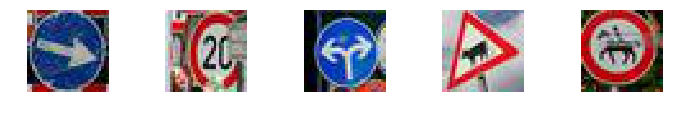

```python
fig, ax = plt.subplots(1, len(external_imgs), figsize=(12, 1.5))
for i, img in enumerate(external_imgs):
    ax[i].axis('off')
    ax[i].imshow(img)
```

```python
external_imgs = normalize(grayscale(external_imgs))
```

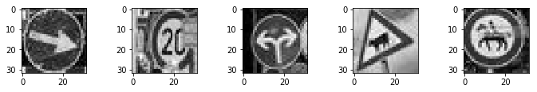

```python
fig, ax = plt.subplots(1, len(external_imgs), figsize=(12, 1.5))
for i, img in enumerate(external_imgs):
    ax[i].imshow(img.squeeze(),cmap='gray')
```

### Predict the Sign Type for Each Image

Note on reproducibility:

1. If the above model 4 has been re-trained again, it may not give the results as illustrated in report. For the following prediction, its model has been backed up in folder 'frozen_final_model'
2. Best practices to reproduce prediction results are restoring the model to working directory, and then executing this notebook from the beginning but skipping the model training. The reason is that the prediction portion below is not standalone, it depends on certain variables/objects defined above.

```python
### Run the predictions here and use the model to output the prediction for each image.
### Make sure to pre-process the images with the same pre-processing pipeline used earlier.
### Feel free to use as many code cells as needed.
```

```python
# Load the lookup table from the csv
sign_lut = pd.read_csv('./signnames.csv')

with tf.Session() as sess:
    saver = tf.train.import_meta_graph('./lenet_model_4.meta')
    saver.restore(sess,"./lenet_model_4") # "./ is required here"
    for i in range(0, external_imgs.shape[0]):
        predicted_id = prediction.eval(session=sess,feed_dict={x : external_imgs[i].reshape([1, 32,32,1])})
        print(predicted_id, sign_lut.ix[predicted_id[0],'SignName'])
```

```
[38] Keep right
[0] Speed limit (20km/h)
[37] Go straight or left
[25] Road work
[10] No passing for vehicles over 3.5 metric tons
```

### Analyze Performance

```python
### Calculate the accuracy for these 5 new images.
### For example, if the model predicted 1 out of 5 signs correctly, it's 20% accurate on these new images.
```

[output not shown]

### Output Top 5 Softmax Probabilities For Each Image Found on the Web

For each of the new images, print out the model's softmax probabilities to show the **certainty** of the model's predictions (limit the output to the top 5 probabilities for each image). [`tf.nn.top_k`](https://www.tensorflow.org/versions/r0.12/api_docs/python/nn.html#top_k) could prove helpful here.

The example below demonstrates how tf.nn.top_k can be used to find the top k predictions for each image.

`tf.nn.top_k` will return the values and indices (class ids) of the top k predictions. So if k=3, for each sign, it'll return the 3 largest probabilities (out of a possible 43) and the correspoding class ids.

Take this numpy array as an example. The values in the array represent predictions. The array contains softmax probabilities for five candidate images with six possible classes. `tk.nn.top_k` is used to choose the three classes with the highest probability:

```
# (5, 6) array
a = np.array([[ 0.24879643,  0.07032244,  0.12641572,  0.34763842,  0.07893497,
         0.12789202],
       [ 0.28086119,  0.27569815,  0.08594638,  0.0178669 ,  0.18063401,
         0.15899337],
       [ 0.26076848,  0.23664738,  0.08020603,  0.07001922,  0.1134371 ,
         0.23892179],
       [ 0.11943333,  0.29198961,  0.02605103,  0.26234032,  0.1351348 ,
         0.16505091],
       [ 0.09561176,  0.34396535,  0.0643941 ,  0.16240774,  0.24206137,
         0.09155967]])
```

Running it through `sess.run(tf.nn.top_k(tf.constant(a), k=3))` produces:

```
TopKV2(values=array([[ 0.34763842,  0.24879643,  0.12789202],
       [ 0.28086119,  0.27569815,  0.18063401],
       [ 0.26076848,  0.23892179,  0.23664738],
       [ 0.29198961,  0.26234032,  0.16505091],
       [ 0.34396535,  0.24206137,  0.16240774]]), indices=array([[3, 0, 5],
       [0, 1, 4],
       [0, 5, 1],
       [1, 3, 5],
       [1, 4, 3]], dtype=int32))
```

Looking just at the first row we get `[ 0.34763842, 0.24879643, 0.12789202]`, you can confirm these are the 3 largest probabilities in `a`. You'll also notice `[3, 0, 5]` are the corresponding indices.

```python
### Print out the top five softmax probabilities for the predictions on the German traffic sign images found on the web.
### Feel free to use as many code cells as needed.
```

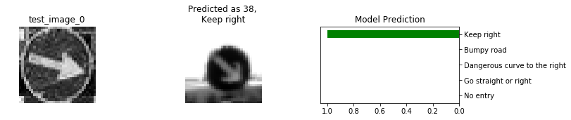

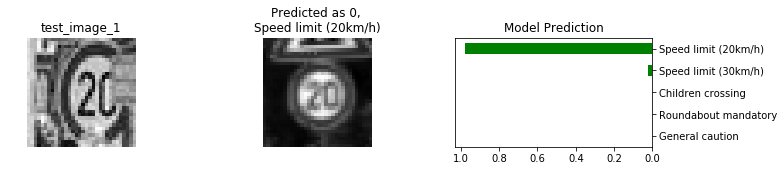

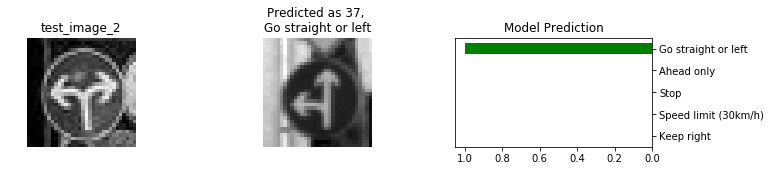

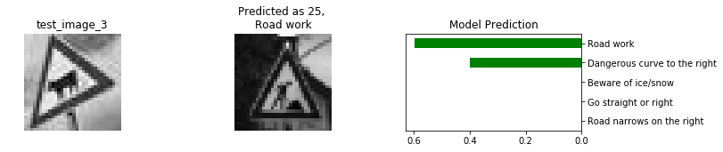

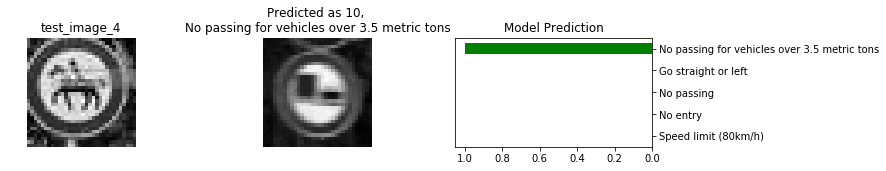

```python
with tf.Session() as sess:
    saver = tf.train.import_meta_graph('./lenet_model_4.meta')
    saver.restore(sess,"./lenet_model_4") # "./ is required here"
    for i in range(0, external_imgs.shape[0]):
        y_prob = np.array(y_hat.eval(session=sess,feed_dict={x : external_imgs[i].reshape([1, 32,32,1])}))
        values, indices = sess.run(tf.nn.top_k(tf.constant(y_prob), k=5))

        # Plot test image
        ind = np.arange(5)
        fig = plt.figure(figsize=(12,2))
        ax = fig.add_subplot(1,3,1)
        ax.axis('off')
        ax.set_title("test_image_" + str(i))
        plt.imshow(external_imgs[i].squeeze(), cmap='gray')

        # Plot in random one of the image of the predicted sign
        index = [i for i, cls in enumerate(y_test) if cls == indices[0,0]]
        choice = np.random.choice(index)

        ax=fig.add_subplot(1,3,2)
        ax.set_title("Predicted as " +  str(y_test[choice]) + ", \n" + sign_lut.ix[y_test[choice],'SignName'])
        ax.axis('off')
        plt.imshow(X_test[choice].squeeze(), cmap='gray')

        # Plot top 5 prediction probability barplot
        ax = fig.add_subplot(1,3,3)
        ax.yaxis.set_ticks_position("right")
        ylabel = list("0")
        ylabel.extend(list(sign_lut.ix[indices[0],'SignName'].values))
        ax.set_yticklabels(ylabel)
        ax.set_title("Model Prediction")
        ax.invert_xaxis()
        ax.invert_yaxis()
        rects1 = ax.barh(ind, values[0], 0.5, color='g')
```

### Project Writeup

Once you have completed the code implementation, document your results in a project writeup using this [template](https://github.com/udacity/CarND-Traffic-Sign-Classifier-Project/blob/master/writeup_template.md) as a guide. The writeup can be in a markdown or pdf file.

## Step 4 (Optional): Visualize the Neural Network's State with Test Images

This Section is not required to complete but acts as an additional excersise for understaning the output of a neural network's weights. While neural networks can be a great learning device they are often referred to as a black box. We can understand what the weights of a neural network look like better by plotting their feature maps. After successfully training your neural network you can see what it's feature maps look like by plotting the output of the network's weight layers in response to a test stimuli image. From these plotted feature maps, it's possible to see what characteristics of an image the network finds interesting. For a sign, maybe the inner network feature maps react with high activation to the sign's boundary outline or to the contrast in the sign's painted symbol.

Provided for you below is the function code that allows you to get the visualization output of any tensorflow weight layer you want. The inputs to the function should be a stimuli image, one used during training or a new one you provided, and then the tensorflow variable name that represents the layer's state during the training process, for instance if you wanted to see what the LeNet lab's feature maps looked like for it's second convolutional layer you could enter conv2 as the tf_activation variable.

For an example of what feature map outputs look like, check out NVIDIA's results in their paper [End-to-End Deep Learning for Self-Driving Cars](https://devblogs.nvidia.com/parallelforall/deep-learning-self-driving-cars/) in the section Visualization of internal CNN State. NVIDIA was able to show that their network's inner weights had high activations to road boundary lines by comparing feature maps from an image with a clear path to one without. Try experimenting with a similar test to show that your trained network's weights are looking for interesting features, whether it's looking at differences in feature maps from images with or without a sign, or even what feature maps look like in a trained network vs a completely untrained one on the same sign image.

[figure not shown]

Your output should look something like this (above)

```python
### Visualize your network's feature maps here.
### Feel free to use as many code cells as needed.

# image_input: the test image being fed into the network to produce the feature maps
# tf_activation: should be a tf variable name used during your training procedure that represents the calculated state of a specific weight layer
# activation_min/max: can be used to view the activation contrast in more detail, by default matplot sets min and max to the actual min and max values of the output
# plt_num: used to plot out multiple different weight feature map sets on the same block, just extend the plt number for each new feature map entry

def outputFeatureMap(image_input, tf_activation, activation_min=-1, activation_max=-1 ,plt_num=1):
    # Here make sure to preprocess your image_input in a way your network expects
    # with size, normalization, ect if needed
    # image_input =
    # Note: x should be the same name as your network's tensorflow data placeholder variable
    # If you get an error tf_activation is not defined it may be having trouble accessing the variable from inside a function
    activation = tf_activation.eval(session=sess,feed_dict={x : image_input})
    featuremaps = activation.shape[3]
    plt.figure(plt_num, figsize=(10,10))
    for featuremap in range(featuremaps):
        plt.subplot(6,6, featuremap+1) # sets the number of feature maps to show on each row and column
        plt.title('FeatureMap ' + str(featuremap)) # displays the feature map number
        plt.axis('off')
        if activation_min != -1 & activation_max != -1:
            plt.imshow(activation[0,:,:, featuremap], interpolation="nearest", vmin =activation_min, vmax=activation_max, cmap="gray")
        elif activation_max != -1:
            plt.imshow(activation[0,:,:, featuremap], interpolation="nearest", vmax=activation_max, cmap="gray")
        elif activation_min !=-1:
            plt.imshow(activation[0,:,:, featuremap], interpolation="nearest", vmin=activation_min, cmap="gray")
        else:
            plt.imshow(activation[0,:,:, featuremap], interpolation="nearest", cmap="gray")
```

```python
index = np.random.randint(0, len(X_train))
image = X_train[index].squeeze()

plt.figure(figsize=(1.5,1.5))
plt.axis('off')
plt.imshow(external_imgs[3].squeeze(), cmap='gray')
```

[output not shown]

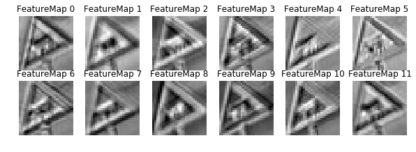

```python
with tf.Session() as sess:
    sess.run(tf.global_variables_initializer())
    saver.restore(sess, tf.train.latest_checkpoint('.'))
    outputFeatureMap(external_imgs[3].reshape([1, 32,32,1]), conv1)
```

```python
image = X_test[11107].squeeze()

plt.figure(figsize=(1.5,1.5))
plt.axis('off')
plt.imshow(image.squeeze(), cmap='gray')
```

[output not shown]

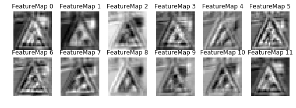

```python
with tf.Session() as sess:
    sess.run(tf.global_variables_initializer())
    saver.restore(sess, tf.train.latest_checkpoint('.'))
    outputFeatureMap(image.reshape([1, 32,32,1]), conv1)
```

```python
image = X_test[2274].squeeze()

plt.figure(figsize=(1.5,1.5))
plt.axis('off')
plt.imshow(image.squeeze(), cmap='gray')
```

[output not shown]

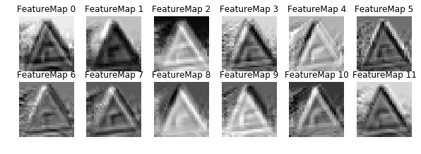

```python
with tf.Session() as sess:
    sess.run(tf.global_variables_initializer())
    saver.restore(sess, tf.train.latest_checkpoint('.'))
    outputFeatureMap(image.reshape([1, 32,32,1]), conv1)
```